# MTA Subway Stations Analysis

Data Analysis Report 2025-11-11

- Introduction
- Analysis
- Conclusion

## Introduction

This report analyzes the MTA Subway Stations dataset to answer key questions about station distribution, naming patterns, directional labels, and geographic characteristics across New York City’s five boroughs.

[figure not shown]

New York City Subway Transit Map

```
## Total number of stations: 496

## Number of unique stations: 493
```

## Analysis

### Question 1: Which borough has the most stations?

**Answer:** Brooklyn has the most stations with **169** stations.

|  | Borough | Number of Stations |
| --- | --- | --- |
| 1 | Brooklyn | 169 |
| 3 | Manhattan | 153 |
| 4 | Queens | 83 |
| 2 | Bronx | 70 |
| 5 | Staten Island | 21 |

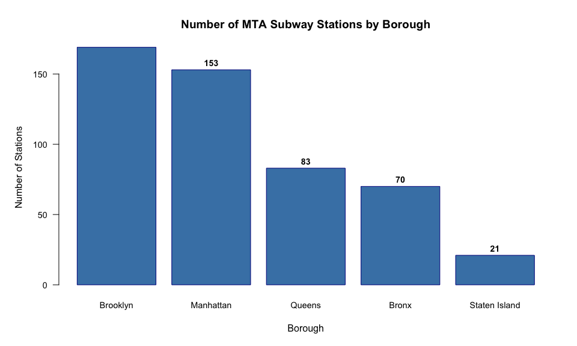

Number of MTA Subway Stations by Borough

### Question 2: How many stops include a number, and how many don’t?

**Answer:** - **211** stops (42.5%) include a number in their name - **285** stops (57.5%) do not include a number

| Category | Count | Percentage |
| --- | --- | --- |
| Stops with Numbers | 211 | 42.5 |
| Stops without Numbers | 285 | 57.5 |

### Question 3: What is the most common North Direction Label and most common South Direction Label?

**Answer:** - **Most common North Direction Label:** Manhattan (appears 143 times) - **Most common South Direction Label:** Manhattan (appears 142 times)

```
## Top 5 North Direction Labels:
```

| Label | Count |
| --- | --- |
| Manhattan | 143 |
| Uptown | 113 |
| Northbound | 61 |
| Outbound | 48 |
| Ferry | 20 |

```
##
##
## Top 5 South Direction Labels:
```

| Label | Count |
| --- | --- |
| Manhattan | 142 |
| Downtown | 130 |
| Southbound | 64 |
| Outbound | 43 |
| South Shore | 18 |

### Question 4: What is the average latitude of Bronx stops vs Staten Island stops?

**Answer:** - **Average latitude of Bronx stops:** 40.848287 degrees - **Average latitude of Staten Island stops:** 40.56871 degrees - **Difference:** 0.279577 degrees (Bronx is north of Staten Island)

| Borough | Average Latitude | Number of Stations |
| --- | --- | --- |
| Bronx | 40.84829 | 70 |
| Staten Island | 40.56871 | 21 |

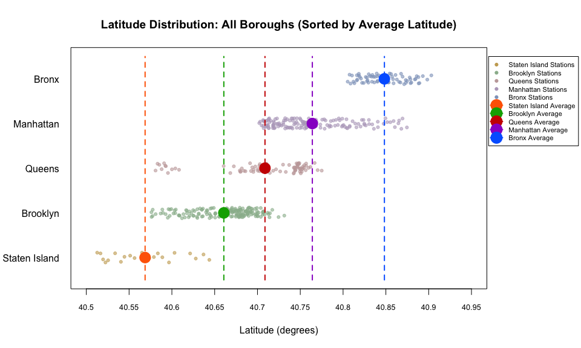

Latitude Distribution: All Boroughs

### Question 5: What is the stop with the highest and lowest latitude?

**Answer:** - **Stop with highest latitude:** Wakefield-241 St (Latitude: 40.903125 degrees) - Borough: Bronx - Line: Lenox - White Plains Rd

- **Stop with lowest latitude:** Tottenville (Latitude: 40.512764 degrees)
  - Borough: Staten Island
  - Line: Staten Island

| Category | Stop_Name | Borough | Latitude |
| --- | --- | --- | --- |
| Highest Latitude | Wakefield-241 St | Bronx | 40.90313 |
| Lowest Latitude | Tottenville | Staten Island | 40.51276 |

## Conclusion

This analysis of the MTA Subway Stations dataset reveals several key insights:

1. **Brooklyn** has the largest number of subway stations among all boroughs, with 169 stations.
2. A significant portion of station names (42.5%) include numbers, which likely reflects the street numbering system used throughout New York City.
3. Directional labels show clear patterns, with **Manhattan** being the most common northbound direction and **Manhattan** being the most common southbound direction.
4. Geographic analysis shows that **Bronx** stations are located at a higher average latitude than **Staten Island** stations, reflecting their relative positions in the New York City metropolitan area.
5. The northernmost station is **Wakefield-241 St**, while the southernmost is **Tottenville**, demonstrating the extensive geographic coverage of the MTA subway system.

These findings provide valuable insights into the distribution and characteristics of New York City’s subway infrastructure across its five boroughs.